# 线性代数：机器学习背后的优化原理

### 4.2、计算矩阵的范数

我们也需要衡量矩阵的大小，对于矩阵大小的衡量在很多优化问题中是非常重要的。而在深度学习中，最常见的做法是使用Frobenius 范数(Frobenius norm)，也称作矩阵的F范数，其定义如下：

$$ \large {\Vert A \Vert}_{F} = \sqrt {\sum_{i,j}{\vert A_{i,j} \vert}^2 } $$

我们这里继续来计算一下F范数

```python
# TODO 实现这里矩阵Frobenius范数计算的函数

""" 计算向量的范数
    参数
        A: 给定的任意二维矩阵 list或者numpy数组形式

    返回
        矩阵的Frobenius范数，float类型数值

"""
# 第一次的错误作答：
# def calc_Frobenius_Norm(A):
#     import cmath
#     sum = 0
#     typeA = A.type()
#     if type != list:
#         shape = A.shape
#         for i in range(shape[0]):
#             for j in range (shape[1]):
#                 sum += (A[i][j])^2
#         sum_sqrt = cmath.sqrt(sum)
#     return sum_sqrt

# 第二次更正：
def calc_Frobenius_Norm(A):
#     print(type(A))#<class 'list'>
#     from tkinter import _flatten
#     Ar = list(_flatten(A))
    k = calc_Norm(A,'fro')
    return(k)
```

```python
%run -i -e test.py LinearRegressionTestCase.test_calc_Frobenius_Norm
```

```
.
----------------------------------------------------------------------
Ran 1 test in 0.001s

OK
```

### 4.3、计算矩阵的条件数

矩阵的条件数(condition number)是矩阵（或者它所描述的线性系统）的稳定性或者敏感度的度量，我们这里为了简化条件，这里只考虑矩阵是奇异矩阵的时候，如何计算以及理解条件数(condition number):

当矩阵A为奇异矩阵的时候，condition number为无限大；当矩阵A非奇异的时候，我们定义condition number如下：

$$ \large \kappa{(A)} = {\Vert A \Vert}_F {\Vert A^{-1} \Vert}_F$$

[奇异矩阵，非奇异矩阵](https://zh.wikipedia.org/wiki/%E9%9D%9E%E5%A5%87%E5%BC%82%E6%96%B9%E9%98%B5)

计算矩阵的条件数

```python
""" 计算矩阵的条件数
    参数
        A: 给定的任意二维矩阵 list或者numpy数组形式

    返回
        矩阵的condition number,

"""
# # 第一次的错误作答：
# def calc_Condition_Number(A):
#     AF = calc_Frobenius_Norm(A)
#     shape = A.shape
#     eye = np.eye(shape[0])
#     AN = eye / A
#     #AN = np.linalg.tensorinv(A, ind=2)
#     ANF = calc_Frobenius_Norm(AN)
#     k = AF * ANF
#     return k

# 需要使用np.linalg.inv来求A的逆
# 并且需要调用之前实现的calc_Frobenius_Norm来运算范数
# 通过A的范数dot 乘 A的逆的范数
# 当然依然有np的方法可以用：np.linalg.cond，要注意参数的变化

# 第二次更正：
# 方法一：
def calc_Condition_Number(A):
    AN = np.linalg.inv(A) #A的逆

    AF = calc_Frobenius_Norm(A)
    ANF = calc_Frobenius_Norm(AN)

    k = np.dot(AF,ANF)# 矩阵的点乘
    return k

#方法二：
# def calc_Condition_Number(A):
#     AC = np.linalg.cond(A, p='fro')
#     return(AC)
```

```python
%run -i -e test.py LinearRegressionTestCase.test_calc_Condition_Number
```

```
.
----------------------------------------------------------------------
Ran 1 test in 0.001s

OK
```

### (选做)4.4、条件数的理解与应用

a. 有如下两个2*2的非奇异矩阵A和B:

$ A = \begin{bmatrix} 1 &2 \\ 3 &4 \\ \end{bmatrix} $

$ B = \begin{bmatrix} 1 &2 \\ 2 &4.0001 \\ \end{bmatrix} $

计算condition number(A), condition number(B);

b. 根据上面构造的矩阵A,B分别计算线性系统方程组的解$w$:

A $ \begin{bmatrix}w_{a1}\\w_{a2}\\ \end{bmatrix} $ = $ \begin{bmatrix}1\\2\\ \end{bmatrix} $,

B $ \begin{bmatrix}w_{b1}\\w_{b2}\\ \end{bmatrix} $ = $ \begin{bmatrix}1\\2\\ \end{bmatrix} $,

A $ \begin{bmatrix}w_{a1}\\w_{a2}\\ \end{bmatrix} $ = $ \begin{bmatrix}{1.0001}\\{2.0001}\\ \end{bmatrix} $,

B $ \begin{bmatrix}w_{b1}\\w_{b2}\\ \end{bmatrix} $ = $ \begin{bmatrix}{1.0001}\\{2.0001}\\ \end{bmatrix} $.

c. 计算完成之后，比较condition number大小与线性系统稳定性之间的关系，并且给出规律性的总结；

**习题4.4** 选做不做算对，虽然没做，但这里也给你一些解释，希望后面继续学习ai的时候你回过头来发现这里有宝藏，哈哈 condition number 是一个矩阵（或者它所描述的线性系统）的稳定性或者敏感度的度量，如果一个矩阵的 condition number 很小，那么它就是well-conditioned的，如果非常大，那么它就是 ill-conditioned 的，如果一个系统是 ill-conditioned 的，它的输出结果就不要太相信了。

这里再解释下ill-conditioned，这种病态条件的线性系统，或者说这种不够稳定的线性系统我们有个名词，中文叫病态系统，那么线性系统 Ax = b 为什么会病态（不稳定）？ 归根到底是由于 A 矩阵列向量线性相关性过大，表示的特征太过于相似以至于容易混淆所产生的。举个例子, 现有一个两个十分相似的列向量组成的矩阵 A：

$ A = \begin{bmatrix} 1000 & 1000 \\ 0 & 0.001 \\ \end{bmatrix} $

在二维空间上，这两个列向量夹角非常小。假设第一次检测得到数据 b = [1000, 0]^T, 这个点正好在第一个列向量所在的直线上，解集是 [1, 0]^T。现在再次检测，由于有轻微的误差，得到的检测数据是 b = [1000, 0.001]， 这个点正好在第二个列向量所在的直线上，解集是 [0, 1]^T。两次求得到了差别迥异的的解集。 （所以照上面的举例来看，是不是可以看出单位矩阵是一个非常稳定的矩阵呢）

d. **阅读与思考**: 考虑更为通用的一种情况，我们计算一个典型的线性回归系统:

$$ Xw = b $$

可以简单推导得出其闭式解为：$ w=(X^TX)^{−1}X^Tb $ ，如果 $X^TX$可逆

推导过程：

1.等式两边乘以$X^T$ $$ X^TXw = X^Tb $$ 2.等式两边乘以$(X^TX)^{-1}$ $$ (X^TX)^{-1}X^TXw = (X^TX)^{−1}X^Tb $$ 3.因为$A^{-1}A = I$，两边约去即可得： $$ w=(X^TX)^{−1}X^Tb $$

hint1. 单位矩阵的condition number是最低的，是最为稳定的；

hint2. 如果要使得该系统存在闭式解，那么就必须使得求逆运算是可以进行的，也就是说重新构造的$X^TX$必须是可逆的方阵；

hint3. 重新构造的方式可以是在$X^TX$基础上进行加或者减或者乘除相关矩阵的操作；

一种可行的方式就是： $$ w = (X^TX+\lambda I)^{−1}X^Tb $$

实际上我们最为常用的[Ridge Regression](http://scikit-learn.org/stable/modules/linear_model.html)和 L2范数以及condition number之间某种程度上是可以相互推导的：

首先，Ridge Regression的损失函数为： $$ J_w = min({\Vert Xw -y \Vert}^2 + \alpha {\Vert w \Vert}^2) $$ 我们展开这个损失函数： $$ {\Vert Xw -y \Vert}^2 + \alpha {\Vert w \Vert}^2 = (Xw -y)^T (Xw-y) + \alpha w^Tw$$ 由于这里是一个凸函数，我们令导数等于零，即为最小值的解，求导可得： $$ X^T (Xw-y) + \alpha w = 0 $$

整理即可得到： $$ w = (X^TX+\lambda I)^{−1}X^Tb $$

1.1.2。岭回归 Ridge回归通过对系数的大小施加惩罚来解决普通最小二乘的一些问题 。脊系数最小化了惩罚的残差平方和， Ridge Regression Ridge regression addresses some of the problems of Ordinary Least Squares by imposing a penalty on the size of coefficients. The ridge coefficients minimize a penalized residual sum of squares,

https://scikit-learn.org/stable/modules/linear_model.html

## 5、SVD

[SVD](https://en.wikipedia.org/wiki/Singular-value_decomposition)是Singular value decomposition的缩写，称为奇异值分解，是分解矩阵的一种方式，会将矩阵分解为奇异向量（singular vector）和奇异值（singular value），分解的意义其实很明确，就是想将一个很大很复杂的矩阵，用更小更简单的几个子矩阵的相乘来表示，这些小矩阵描述的是矩阵的重要的特性。

那么SVD具体的数学表达是什么呢？

假设有一个矩阵C，我们可以将矩阵C分解为三个矩阵的乘积：

[figure not shown]

$$\large C = UDV^{T}$$

如果C是一个m x n的矩阵，那么U是一个m x m的矩阵，D是一个m x n的矩阵，V是一个n x n的矩阵，这些小矩阵并不是普普通通的矩阵，U和V都定义为正交矩阵，而D定义为对角矩阵。

SVD最常用的做法就是用来进行特征的降维以及矩阵的低秩重构，例如这里分别取矩阵U、D、VT的前k列，如图示中的白色部分，然后重新计算新的C矩阵，即为k维度下的矩阵重构，这种方法被广泛应用于自然语言处理[LSA](https://en.wikipedia.org/wiki/Latent_semantic_analysis)、推荐系统[SVD++,FM,FFM](https://tech.meituan.com/deep_understanding_of_ffm_principles_and_practices.html)等领域，如有兴趣可以继续参考链接相关资料。

[figure not shown]

具体计算UDV的算法不是我们这个项目的关键，我们只需使用numpy得出结果即可，下面的习题，将会带你体会SVD的某一应用场景。

提示：我们会需要使用[numpy.linalg](https://docs.scipy.org/doc/numpy-1.13.0/reference/routines.linalg.html)相关函数。

下面来对这三道选做题进行一些解释： 对于奇异值,在奇异值矩阵中也是按照从大到小排列，而且奇异值的减少特别的快，在很多情况下，前10%甚至1%的奇异值的和就占了全部的奇异值之和的99%以上的比例。也就是说，我们也可以用最大的k个的奇异值和对应的左右奇异向量来近似描述矩阵。也就是说： ps:下划线后的数据代表小标，指几乘几矩阵 A_m×n=(U_m×m)(Σ_m×n)(VT_n×n)≈(U_m×k)(Σ_k×k)(VT_k×n) 其中k要比n小很多，也就是一个大的矩阵A可以用三个小的矩阵U_m×k,Σ_k×k,VT_k×n来表示,由于这个重要的性质，SVD可以用于[PCA](https://zh.wikipedia.org/zh-hans/%E4%B8%BB%E6%88%90%E5%88%86%E5%88%86%E6%9E%90)降维，来做数据压缩和去噪。也可以用于推荐算法，将用户和喜好对应的矩阵做特征分解，进而得到隐含的用户需求来做推荐。同时也可以用于NLP中的算法，比如潜在语义索引（LSI）。

### 5.1、使用numpy去计算任意矩阵的奇异值分解：

```python
""" 计算任意矩阵的奇异值分解
    参数
        A: 给定的任意二维矩阵 list或者numpy数组形式

    返回
        使用numpy.linalg相关函数，直接返回分解之后的矩阵U,D,V
        （可以尝试一下使用np.shape一下分解出来的U，D，VT，会发现维度跟我们上面讲解所描述的不同，
        暂时不用管他直接返回np求解出的U，D，VT即可）

"""
def calc_svd(A):
    u,v,w=np.linalg.svd(A,full_matrices=0,compute_uv=1)
#     C = np.dot(u,np.dot(v,w)) #检验一下
#     print('C=',C)
    return u,v,w  #, C
```

```python
%run -i -e test.py LinearRegressionTestCase.test_calc_svd
```

```
.
----------------------------------------------------------------------
Ran 1 test in 0.024s

OK
```

### (选做) 5.2、利用奇异值分解对矩阵进行降维

```python
# TODO 利用SVD进行对于矩阵进行降维

""" 利用SVD进行对于矩阵进行降维
    参数
        A: 给定的任意二维矩阵 list或者numpy数组形式 shape为(m,n)
        topk: 降维的维度 (m,n) -> (m,topk)

    返回
        降维后的矩阵 (m, topk)

    hint
    1. 对角矩阵D存在一个较为明显的特性，就是D的对角线元素是递减的，这些元素实际上是衡量了所分解的矩阵U,V的列向量的重要性
    2. 因此我们常说的svd降维就是利用选取的前topk大的对角线矩阵元素进行构造新的降维矩阵
    3. U的按照前topk截取的列向量 * topk截取的对角矩阵 即为新的降维后的矩阵

"""
#第一次的错误作答
# def calc_svd_decompostion(A, topk = 2):
#     u,v,w, C = calc_svd(A)

#     v[topk-1:]=0 # 降维
#     print("v=",v)

#     S = np.zeros((2,3))
#     S[:2, :2] = np.diag(v)
#     m =  np.dot(np.dot(A.T, u), S)
#     print("A conv:",m) # 原始数据转到低维
#     return(m)

#更正
def calc_svd_decompostion(A, topk = 2):
    u,d,vt = calc_svd(A)
    return np.dot(u[:, :topk],np.diag(d[:topk]))
```

```python
%run -i -e test.py LinearRegressionTestCase.test_calc_svd_decompostion
```

```
.
----------------------------------------------------------------------
Ran 1 test in 0.259s

OK
```

### (选做) 5.3、利用奇异值分解对矩阵进行降维后重构

```python
""" 利用SVD进行对于矩阵进行降维
    参数
        A: 给定的任意二维矩阵 list或者numpy数组形式 shape为(m,n)
        topk: 降维的维度 (m,n) -> (m,topk)

    返回
        降维重构后的矩阵 (m, n)
    hint
        这里除了降维矩阵外，另外一个较为常见的应用就是对矩阵进行重构，具体的做法类似前面的思路
        1. 选取对应的U，D，V的topk向量
        2. U的按照前topk截取的列向量 * topk截取的对角矩阵 * V^T按照前topk截取的行向量(注意这里是V的转置,因为分解得到的是V^T)

"""
#第一次的错误作答
# def calc_svd_reconsitution(A, topk = 2):
#     C = np.dot(np.dot(u, S), w)
#     print("C:",C ) # 恢复原始维度

#更正
def calc_svd_reconsitution(A, topk = 2):
    u,d,vt = calc_svd(A)
    return np.dot(np.dot(u[:, :topk],np.diag(d[:topk])), vt[:topk,:])
```

```python
%run -i -e test.py LinearRegressionTestCase.test_calc_svd_reconsitution
```

```
.
----------------------------------------------------------------------
Ran 1 test in 0.174s

OK
```

### (选做) 5.4、计算不同降维大小重构矩阵的Frobenius范数损失

定义矩阵$A$以及使用SVD降维（降维大小为k)分解后的重构矩阵$A_k$，则这里的F范数损失定义如下：

$$ \Large Loss_{F} = {\Vert A - A_k \Vert}_F $$

这里需要编码求出对于给定的矩阵A 分别在不同的降维幅度下重构后的F范数损失，并且作出损失大小随着降维大小的变化图：

```python
## 不要修改这里！
import numpy as np
from sklearn.datasets import load_boston
import matplotlib.pyplot as plt
%matplotlib inline
A = load_boston()['data']  # 载入boston house 数据集
print(A.shape)
```

```
(506, 13)
```

```
Text(0,0.5,'F Loss')
```

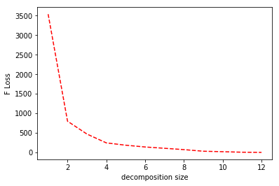

```python
loss_hist = []
for topk in range(1,13):
    # 5.4 TODO
    ### 1.计算相应的SVD topk降维后的重构矩阵，需实现calc_svd_reconsitution
    ### 2.计算对应的F范数损失，并存储loss放入loss_hist列表中

#     #第一次的错误作答：
#     (U, S, VT) = np.linalg.svd(M)#对数据矩阵M进行奇异值分解
#     #根据percentage求k值
#     new_U  = U[:len(U), :k]
#     new_VT = VT[:k, :len(VT)]
#     #损失
#     L = A-Ak
#     calc_Frobenius_Norm(L)

    #更正
    AK = calc_svd_reconsitution(A,topk = topk)
    loss_hist.append(calc_Frobenius_Norm(A - AK))

### 画出F损失随着降维大小的变化图
### x坐标为对应的降维大小，y坐标为对应的F损失
plt.plot(range(1,13),loss_hist,'r--')
plt.xlabel('decomposition size')
plt.ylabel('F Loss')
```

### 5.5、SVD的有趣应用

为了这个习题我准备了两张图，参见项目文件夹下的test_girl.jpg和test_boy.jpeg，自选一张，你需要

- 需要使用 `PIL` **加载**你所选择的图像（[文档](https://pillow.readthedocs.io/en/latest/reference/Image.html)）,所以记得**导入**需要的包（模块）
- 使用Image的[convert方法](https://pillow.readthedocs.io/en/latest/reference/Image.html#PIL.Image.Image.convert)将图像变为**灰度图**
- 将convert后的结果**转换**成np.array,需用到[Image.getdata方法](https://pillow.readthedocs.io/en/latest/reference/Image.html#PIL.Image.Image.getdata)来**读取**图片每个pixel的数据，特别注意一下，对于彩色的图来说，即使我们转为了灰度图，但每一个pixel还是由RGB三个维度组成，所以在getdata时，band需要设定为某一个颜色index，比如band = 0，这样只用R这个维度的数据。用这个方法来**保证图片的每个pixel只占有一个单元的空间**。
- 因为我们转np.array时破坏了原有图形的样子，变成了一个一维数据，我们要将转换后的np.array**恢复**到图片应有的size，转换后，可以shape**确认**下是否与最开始转出的灰度图的size一致，注意图的size是（宽，高），而宽对应array.shape的应该是列，而高对应的是行，别弄反了。
- 使用上方实现的calc_svd函数计算上一步**计算**出的np.array数据，赋值给变量：U,D,VT
- 打印出U,D,VT的shape形状，尤其注意观察D的shape
- 在U，VT，D变量成功实现的情况下，运行测试程序看效果

**掌握奇异值分解的原理，能够理解奇异值分解最常见的两个应用，降维以及矩阵重构，成功实现了编程求解，通过了单元测试。**

**额外的提示**

要注意提示各个流程的顺序 （ 打开图像open

转为黑白convert

获取图像数据getdata

将数据转为np.array

还原图像大小reshape

计算svd ）

```python
# 5.5 TODO

#第一次的错误作答：
    #导入图像
    #奇异值分解过程
    #选取前面14个非零奇异值

    #左奇异矩阵
    #右奇异矩阵

    #同时输出两个图片
#线性代数还是想学好的，因为数学是继续下去的基础啊……可是我看不懂……这份项目还是想坚持完的
```

```
imgL_size: (750, 600)
imga: (450000,)
#3:修改：np.shape(img) (600, 750, 3)
imgr_shape: (600, 750)
imgr: [[ 78  79  80 ...  95  96  98]
 [ 78  79  80 ...  96  97  99]
 [ 79  79  79 ...  97  98 100]
 ...
 [ 41  41  40 ... 239 239 238]
 [ 43  42  41 ... 240 239 239]
 [ 42  41  40 ... 239 238 237]]
(600, 600) (600,) (600, 750)
D= [8.65105103e+04 2.23485792e+04 1.66315649e+04 1.45556903e+04
 7.66274427e+03 7.05611811e+03 6.41671632e+03 5.59856210e+03
 4.99108363e+03 4.36569370e+03 4.13091468e+03 3.67261132e+03
 3.48045688e+03 2.63918485e+03 2.50393482e+03 2.37461723e+03
 2.15451939e+03 1.95270679e+03 1.85844273e+03 1.79368140e+03
 1.72727658e+03 1.60208465e+03 1.54519416e+03 1.45312205e+03
 1.36045575e+03 1.26595970e+03 1.19753379e+03 1.17782596e+03
 1.13784534e+03 1.12972475e+03 1.09257656e+03 1.05063884e+03
 1.00585910e+03 9.52112475e+02 9.31056388e+02 8.85165697e+02
 8.42618291e+02 7.99342410e+02 7.87775143e+02 7.63226777e+02
 7.59538894e+02 7.23088281e+02 7.11081842e+02 6.85299155e+02
 6.56460569e+02 6.53672021e+02 6.31789207e+02 6.10055592e+02
 5.94277588e+02 5.82268047e+02 5.73782714e+02 5.65645229e+02
 5.47768098e+02 5.45810613e+02 5.29275874e+02 5.04946036e+02
 4.95588464e+02 4.88700722e+02 4.77575241e+02 4.66742324e+02
 4.58582678e+02 4.52270334e+02 4.43390140e+02 4.36721310e+02
 4.20611726e+02 4.17408353e+02 4.12042896e+02 3.97693374e+02
 3.90969944e+02 3.81365160e+02 3.79622304e+02 3.74797804e+02
 3.66328510e+02 3.62280944e+02 3.53400215e+02 3.45683020e+02
 3.39432290e+02 3.35206361e+02 3.26922358e+02 3.23818127e+02
 3.23336839e+02 3.16533864e+02 3.13323745e+02 3.11985142e+02
 3.08433094e+02 3.00510890e+02 2.94602062e+02 2.87890407e+02
 2.85904507e+02 2.81355318e+02 2.77423848e+02 2.70567234e+02
 2.67737876e+02 2.63547368e+02 2.59275035e+02 2.57060474e+02
 2.55297648e+02 2.53961855e+02 2.52326469e+02 2.48907362e+02
 2.46006728e+02 2.43553292e+02 2.40995972e+02 2.38544286e+02
 2.33866030e+02 2.31278681e+02 2.29335607e+02 2.23838977e+02
 2.20977590e+02 2.18074277e+02 2.16215373e+02 2.15132149e+02
```

[output cut: 107 more lines]

```
 5.37963014e+00 5.34034803e+00 5.26073853e+00 5.18425067e+00
 5.17446032e+00 5.15545630e+00 5.05279345e+00 5.02352675e+00
 5.00709550e+00 4.93844407e+00 4.89324146e+00 4.81777050e+00
 4.78650064e+00 4.70092890e+00 4.63924363e+00 4.59585350e+00
 4.55621615e+00 4.46631236e+00 4.42364825e+00 4.41133844e+00
 4.34169187e+00 4.28805878e+00 4.26707469e+00 4.18094973e+00
 4.08878203e+00 4.05910620e+00 4.02660179e+00 3.94632412e+00
 3.88932908e+00 3.83562582e+00 3.74092783e+00 3.67649695e+00
 3.66725075e+00 3.64771885e+00 3.57254976e+00 3.56031235e+00
 3.53269508e+00 3.50346778e+00 3.44180334e+00 3.36381183e+00
 3.30395182e+00 3.25989377e+00 3.20450497e+00 3.13393306e+00
 3.08194754e+00 3.03235500e+00 2.98737638e+00 2.94630197e+00
 2.88343256e+00 2.84049706e+00 2.67743739e+00 2.62630000e+00
 2.57233504e+00 2.50047975e+00 2.44721429e+00 2.34606168e+00
 2.30396983e+00 2.18151638e+00 2.14771218e+00 1.97773063e+00]
```

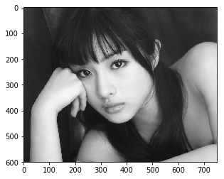

```python
from PIL import Image
img = Image.open("test_girl.jpg")#test_girl.jpg , test_boy.jpeg
imgL = img.convert('L')
print("imgL_size:",np.size(imgL))#图的size是（宽，高）
imgdata = img.getdata(band = 0)#4.修改：增加了band=0参数
imga = np.array(imgdata)
print("imga:",np.shape(imga)) #转np.array时破坏了原有图形的样子，变成了一个一维数据

print("#3:修改：np.shape(img)",np.shape(img))
s = np.shape(img)
s0, s1 = s[0],s[1]
imgr = imga.reshape(s0, s1) ## 3.疑问？cannot reshape array of size 1350000 into shape (600,750)
#不能reshape一个赋了值的变量？4.解答：这样没有问题

print("imgr_shape:",np.shape(imgr))#宽对应array.shape的应该是列，而高对应的是行
print("imgr:",imgr)

U,D,VT = calc_svd(imgr)##3.imga 1-dimensional array given. Array must be at least two-dimensional #4.更正为imgr
print(np.shape(U),np.shape(D),np.shape(VT))
print("D=",D)
plt.imshow(imgL)
```

```python
# #3 修改：
# from PIL import Image
# img = Image.open("test_girl.jpg")#test_girl.jpg , test_boy.jpeg
# imgL = img.convert('L')
# imgdata = img.getdata(band = 0) #默认值是返回所有带区。要返回单个波段，传递索引值（例如0，从“rgb”图像中获取“r”波段）
# imga = np.array(imgdata)
# imgr = imga.reshape(600, 750)#图像的size ##
# U,D,VT = calc_svd(imgr)
```

##### 版本 4 解答：

问题主要是出在： imgdata = img.getdata（band = 0） 注意参数

这个部分的解释参考项目： 将转换后的结果转换成np.array，需用到Image.getdata方法来读取图片每个像素的数据，特别注意一下，对于彩色的图来说，即使我们转为了灰度图，但每一个像素还是由RGB三个维度组成，所以在getdata时，带需要设定为某一个颜色索引，比如带= 0，这样只用R这个维度的数据。用这个方法来保证图片的每个像素只占有一个单元的空间。 原因是我们本身的图片是彩色的，它是由红绿蓝3层维度数据组成，但我们只需要一层来进行分解。

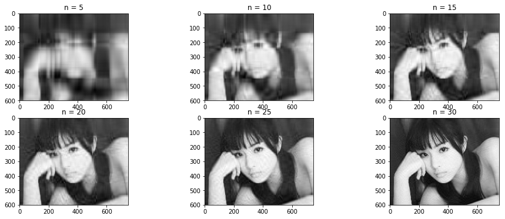

```python
#请在U，D，V变量完成的情况下调用此测试程序，不要修改此处
plt.figure(figsize=(16,6))
for i,topk in enumerate([5, 10, 15, 20, 30, 50]):
    reconstimg = np.matrix(U[:, :topk]) * np.diag(D[:topk]) * np.matrix(VT[:topk, :])
    plt.subplot(231+i)
    plt.imshow(reconstimg, cmap='gray')
    title = "n = %s" % ((i+1)*5)
    plt.title(title)
plt.show()
```

相关继续深入学习的资料：

1. [机器学习与优化](http://freemind.pluskid.org/series/mlopt/)
2. [PCA与SVD的区别](https://www.zhihu.com/question/40043805/answer/138429562)
3. [SVD在降维中的应用](https://www.cnblogs.com/pinard/p/6251584.html)
4. [SVD在自然语言处理中的应用](https://blog.csdn.net/pipisorry/article/details/42560331)
5. [SVD在推荐系统中的应用](https://tech.meituan.com/deep_understanding_of_ffm_principles_and_practices.html)
6. [《Elements of Statistical Learning》Trevor Hastie, Robert Tibshirani, and Jerome Friedman](https://web.stanford.edu/~hastie/ElemStatLearn//)